# exercise_1

## NumPy - co trzeba wiedzieć

- Jak stworzyć tablicę (1D/2D/3D):
  - wypełnioną zerami, jedynkami
  - wypełnioną danymi podanymi jako lista pythona

```python
import numpy as np

# tworzenie tablicy wypelnionej zerami
img = np.zeros((3,5)) # 3 wiersze, 5 kolumn
print(img)
```

```
[[0. 0. 0. 0. 0.]
 [0. 0. 0. 0. 0.]
 [0. 0. 0. 0. 0.]]
```

```python
img = np.ones((3,5), dtype=np.uint8) # wymuś typ byte (0-255)
print(img)
```

```
[[1 1 1 1 1]
 [1 1 1 1 1]
 [1 1 1 1 1]]
```

```python
img = np.array([[11,12,13],[21,22,23]])
print(img)
```

```
[[11 12 13]
 [21 22 23]]
```

```python
# tworzenie tablicy wypelnionej kolejnymi liczbami
img = np.arange(10)
print(img)
```

```
[0 1 2 3 4 5 6 7 8 9]
```

- `tablica.shape` — wymiary tablicy
- `tablica.dtype` — typ elementów w tablicy

```python
img = np.array([[11,12,13],[21,22,23]])
print(img)
print(img.shape)
print(img.dtype)
print(img.astype(float))  # konwersja typu elementów tablicy
```

```
[[11 12 13]
 [21 22 23]]
(2, 3)
int64
[[11. 12. 13.]
 [21. 22. 23.]]
```

- Jak zaindeksować pojedynczy element tablicy (dla obrazów: **najpierw nr wiersza** potem nr kolumny).
- Jak odwoływać się do zakresów: `tablica[start_włącznie:koniec_bez:krok]`

```python
# fragment tablicy - przypadek 1D
img = np.arange(10)
print(img[1:9])     # zakres od indeksu 1 włącznie do 9 (z wyłączeniem 9)
print(img[0:10:2])  # co druga wartość
print(img[10:0:-1]) # z krokiem -1 (czyli od tył), UWAGA: element o indeksie 0 nie należy do wyniku!
print(img[10::-1])  # z krokiem -1 (czyli od tył),
print(img[::-1])    # wynik jak wyżej (cały zakres, z krokiem -1)
```

```
[1 2 3 4 5 6 7 8]
[0 2 4 6 8]
[9 8 7 6 5 4 3 2 1]
[9 8 7 6 5 4 3 2 1 0]
[9 8 7 6 5 4 3 2 1 0]
```

```python
# ujemne indeksy: liczymy od końca
print(img)
print(img[0:-2])
```

```
[0 1 2 3 4 5 6 7 8 9]
[0 1 2 3 4 5 6 7]
```

```python
# tworzenie tablicy 2D wypelnionej kolejnymi liczbami
img = np.arange(15).reshape((3,5))
print(img)
print(img.shape) # wymiary tablicy
```

```
[[ 0  1  2  3  4]
 [ 5  6  7  8  9]
 [10 11 12 13 14]]
(3, 5)
```

```python
# fragment tablicy - przypadek 2D
print(img[1,3])      # pojedynczy element z wiersza(!) o indeksie 1 i kolumnie o indeksie 3
print(img[1:3])      # nie indeksujemy kolumn (ogólnie: jakiegoś wymiaru) więc interesują nas wszystkie
print(img[1:3,:])    # jak wyżej, jawnie podany cały zakres
print(img[1:3,2])    # konkretny wiersz, UWAGA: wynik jest tablicą o mniejszej liczbie wymiarów (tutaj: wektor 1D)!
print(img[1:3,2:3])  # zakres wiersz - nie następuje redukcja wymiarów (wynik 2D)
print(img[1:3,::2])  # dla każdy wymiaru można podawać dowolny zakres
```

```
8
[[ 5  6  7  8  9]
 [10 11 12 13 14]]
[[ 5  6  7  8  9]
 [10 11 12 13 14]]
[ 7 12]
[[ 7]
 [12]]
[[ 5  7  9]
 [10 12 14]]
```

- Odwołanie się do fragmentu (lub całości) jakiejś tablicy nie powoduje utworzenia kopii danych! Czyli modyfikując wycięty fragment tablicy modyfikujemy wybrane elementy oryginalnej tablicy.

```python
# kopiowanie
a = np.arange(5)
b = a
c = a.copy()
print(a,b,c)
b[2] = 8
print(a,b,c)
```

```
[0 1 2 3 4] [0 1 2 3 4] [0 1 2 3 4]
[0 1 8 3 4] [0 1 8 3 4] [0 1 2 3 4]
```

```python
img = np.arange(15).reshape((3,5))
print(img)
fragment = img[1,2:4]
fragment[:] = -8
print(img)
print(fragment)
```

```
[[ 0  1  2  3  4]
 [ 5  6  7  8  9]
 [10 11 12 13 14]]
[[ 0  1  2  3  4]
 [ 5  6 -8 -8  9]
 [10 11 12 13 14]]
[-8 -8]
```

- Standardowe operacje arytmetyczne jak dodawanie i mnożenie(!) na argumentach będących tablicami wykonują operacje na odpowiadających sobie elementach. Podobnie – funkcje takie jak np.sin obliczają swoją wartość dla każdego elementu podanej tablicy. **Uwaga!** W szczególności mnożenie (*) nie jest mnożeniem macierzowym!

```python
# prosta arytmetyka
a = np.arange(5)
b = a * 2
print(a, b)

c = a + b
print(c)
print(a + b - c)
```

```
[0 1 2 3 4] [0 2 4 6 8]
[ 0  3  6  9 12]
[0 0 0 0 0]
```

```python
# operacje logiczne
tab = np.arange(10)
print(tab < 5)
print(tab == 5)
print(np.logical_or(tab < 2, tab > 6))
print((tab < 2) | (tab > 6)) # alternatywny zapis - wynik jak wyżej (proszę zwrócić uwagę na nawiasy!)
```

```
[ True  True  True  True  True False False False False False]
[False False False False False  True False False False False]
[ True  True False False False False False  True  True  True]
[ True  True False False False False False  True  True  True]
```

- Funkcje takie jak `np.sum` czy `np.max` wyliczają wartość z całej tablicy, lub po określonej osi.

```python
img = np.arange(15).reshape((3,5))
print(img)
print(np.sum(img), img.sum())
print(np.mean(img, axis=0))
print(np.min(img, axis=1))
```

```
[[ 0  1  2  3  4]
 [ 5  6  7  8  9]
 [10 11 12 13 14]]
105 105
[5. 6. 7. 8. 9.]
[ 0  5 10]
```

- Jak odwoływać się do wybranych elementów: `tablica[boolowska_tablica]` (np. spełniających kreślony warunek: `tablica[tablica < 10]`)

```python
tab = np.arange(10)
# cond = np.logical_and(tab >= 2, tab <= 7)
cond = (tab >= 2) & (tab <= 7)
print(cond)
print(tab[cond])
```

```
[False False  True  True  True  True  True  True False False]
[2 3 4 5 6 7]
```

# Obrazki

Przygotowania...

```python
# poniższa linijka mówi jupyter'owi żeby obrazki wyświetlał tutaj jako wynik wykonania komórki
%matplotlib inline
import numpy as np
import matplotlib.pyplot as plt
import skimage.io as io
import skimage.data as data
import skimage.color as color
import skimage
```

Wczytaj i wyświetl przykładowy obrazek:

[figure not shown]

```python
# opcjonalnie można ustawić dpi i wielkość obrazka w calach
import matplotlib as mpl
mpl.rc("savefig", dpi=100)
plt.figure(figsize=(10, 10))

img = data.astronaut()
#img = io.imread('plik na dysku lub adres obrazka w sieci.png')
io.imshow(img)
```

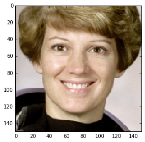

```python
io.imshow(img[50:200,150:300]) # Wycięcie fragmentu obrazka
```

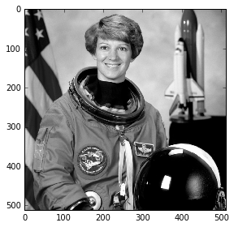

```python
io.imshow(color.rgb2grey(img)) # Konwersja obrazku do odcieni szarości

# io.imread ma parametr as_grey do konwersji przy wczytywaniu
# img = io.imread('plik na dysku lub adres obrazka w sieci.png', as_grey=True)
```

Alternatywne wyświetlenie obrazka w zewnętrznym programie:

##### UWAGA! Musisz zamknąć zewnętrzny program aby kod dalej się wykonywał

```python
from scipy.misc import toimage
toimage(img).show()
print("KONIEC")
```

```
KONIEC
```

# Ćwiczenia:

- Napisz funkcję zliczającą liczbę różniących się pikseli pomiędzy dwoma obrazkami (zakładamy taki sam rozmiar obrazków).

  **Uwaga:** obrazki mogą być albo kolorowe (3 kanały: tablica o wymiarach `width x height x 3`) albo jednokanałowe (tablica o wymiarach `width x height`)

  **Uwaga ogólna:** gdy mówimy o obrazie **jednokanałowym** mamy na myśli tablicę o rozmiarze:
  - `width x height` (dwa wymiary)
  - a **NIE** `width x height x 1` (trzy wymiary)!

```python
def cmpDiff(ground_true, im_test):
    x, y, *z = ground_true.shape
    if z == [3]:
        diff = ground_true != im_test
        return diff.any(2).sum()
    else:
        diff = ground_true != im_test
        return diff.any(1).sum()
```

```python
img1 = data.astronaut()
img2 = img1.copy()
img2[10,10] = (0,255,255)
assert cmpDiff(img1, img2) == 1
```

```python
# One channel
image_1 = color.rgb2grey(data.astronaut())
image_2 = image_1.copy()
image_2[0, 0] = 244
assert cmpDiff(image_1, image_2) == 1
```

- Napisz funkcję porównującą dwa obrazki jednokanałowe interpretowane **binarnie** (punkty mają wartość 0 lub różną od zera) i zwracającą dwie wartości:
  1. false positive – powinno być zero a nie jest,
  2. false negative – jest zero a nie powinno być.

```python
def cmpTPTN(im_true, im_test):
    FP = ((im_true == 0) & (im_test != 0)).any(1).sum()
    FN = ((im_true != 0) & (im_test == 0)).any(1).sum()
    return FP, FN
```

- Przetestuj działanie rozmycia gaussowskiego:

```python
import ipywidgets
img = data.camera()
import skimage.filters

sigma_slider = ipywidgets.FloatSlider(min=0, max=50, step=1, value=1)
@ipywidgets.interact(sigma=sigma_slider)
def gaussian_demo(sigma=5):
    io.imshow(skimage.filters.gaussian(img, sigma))
```

# Postaraj się wykryć obiekt(y) w obrazkach (abc i uniform to obrazki które należy wczytać z dysku):

1. task1 = abc + (uniform - 127)
2. task2 = abc + 1.1*(uniform - 127)
3. task3 = abc + 1.5*(uniform - 127)

Przez wykrycie należy rozumieć wygenerowanie obrazka-maski w której w miejscach gdzie jest obiekt mamy wartość większą od 0, a zera w miejscach gdzie nie ma obiektu. Do porównywania swoich wyników wykorzystaj funkcje `cmpDiff`, `cmpTPTN` z poprzednich ćwiczeń.

Czy udało Ci się zminimalizować różnicę do zera?

Przydatne funkcje, np.: `gaussian`, `median`

**Uwaga:** Jaki typ ma tablica `abc` i `uniform`? Zwróć uwagę co się dzieje, gdy wartości wychodzą poza oryginalny zakres 0-255. Wykonując operacje artymetyczne przejdź na odpowiedni typ danych, a następnie przytnij wartości do zakrsu 0-255 (np.clip) i wróć do typu `np.uint8`.

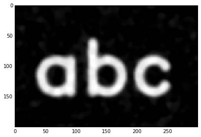

```python
from skimage.morphology import disk

abc = io.imread('components/objects/abc.png', as_grey=True).astype(np.float)
uniform = io.imread('components/noise/uniform.png', as_grey=True).astype(np.float)
# Na początku np.uint8, samemu force na float aby wykonywać operacje

task1 = abc + (uniform - 127)
x = skimage.filters.gaussian(task1, 3).clip(0, 255).astype(np.uint8)
x = skimage.filters.median(x, disk(5))
io.imshow(x)

task2 = abc + 1.1*(uniform - 127)
x = skimage.filters.gaussian(task2, 3).clip(0, 255).astype(np.uint8)
x = skimage.filters.median(x, disk(5))
io.imshow(x)

task3 = abc + 1.5*(uniform - 127)
x = skimage.filters.gaussian(task3, 3).clip(0, 255).astype(np.uint8)
x = skimage.filters.median(x, disk(5))
io.imshow(x)
```

# Wykryj obiekty w obrazku: 0.2 * abc + 0.8 * circular.

Podobne obrazki: [PiRO](http://www.cs.put.poznan.pl/bwieloch/PiRO/piro_grey.png) oraz [zaszumione PiRO](http://www.cs.put.poznan.pl/bwieloch/PiRO/piro_noise_grey.png).

Potencjalnie przydatne funkcje: `threshold_adaptive`

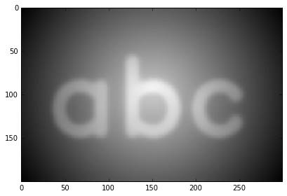

```python
abc = io.imread('components/objects/abc.png', as_grey=True).astype(np.float)
circular = io.imread('components/gradient/circular.png', as_grey=True).astype(np.float)

task1 = 0.2 * abc + 0.8 * circular
x = skimage.filters.gaussian(task1, 3).clip(0, 255).astype(np.uint8)
x = skimage.filters.median(x, disk(5))
io.imshow(x)
```